# Using detectnorm in meta-analysis

Rong Wei Sun & Shu Fai Cheung

2022-07-15

## Introduction

The goal of `detectnorm` is to speculate the skewness and kurtosis based on the Beta and truncated normal distribution. When conducting a meta-analysis for two independent groups, we generally retrieved very limited statistics from primary studies, and it is hard to access the raw data. However, the non-normality of raw data could influence the meta-analytic results greatly (Sun & Cheung, 2020). This package allows meta-analysis researchers to speculate the skewness and kurtosis of the raw data, even without the raw data. Instead of normal distribution, if the researcher believes the population distribution is non-normal, then beta-distribution could be a good choice. If the researcher believes the population distribution is normal but truncated by the measuring ability of the instrument, then truncated normal distribution is a good option. The package provides not only the skewness and kurtosis estimates but also the figures to visualize them. Now, this package could work directly with the standardized mean difference for two independent groups. It also works for one group of data.

```r
library(detectnorm)
```

## Example

This is a basic example which shows you how to solve a common problem:

For one study if you assumed non-normal distribution in population:

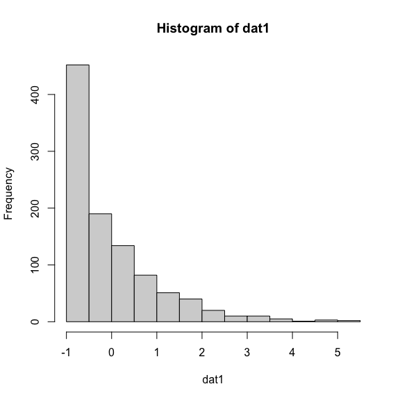

```r
library(detectnorm)
# Situations using beta distributions
set.seed(32411)
#Using Fleishman's method to generate non-normal data
dat1 <- rnonnorm(n = 1000, mean = 0, sd = 1, skew = 2, kurt = 5)$dat
hist(dat1)
```

```r
psych::describe(dat1)
```

```
#>    vars    n  mean sd median trimmed  mad   min  max range skew kurtosis   se
#> X1    1 1000 -0.01  1  -0.38    -0.2 0.63 -0.84 5.31  6.15 1.88     4.16 0.03
```

```r
#Suppose we don't know about the raw data
result <- desbeta(vmean = mean(dat1), vsd = sd(dat1),lo = min(dat1), hi = max(dat1), showFigure = TRUE, rawdata = dat1)
```

```
#> [1] "mean is -0.0125212643739019"
#> [1] "sd is 0.999848046282588"
#> [1] "min. is -0.839243624241584"
#> [1] "max. is 5.31239864959992"
```

```r
result
```

```
#> $dat
#>       alpha     beta      mean        sd skewness kurtosis
#> 1 0.4574073 2.946161 0.1343905 0.1625335 1.665152 2.572622
#>
#> $fig
```

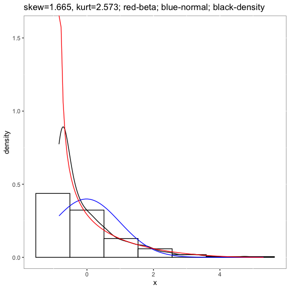

For one study if you assumed normal distribution in population with truncated by the measurements:

```r
library(detectnorm)
#Truncated normal distribution
set.seed(34120)
dat2 <- truncnorm::rtruncnorm(n = 1000, a = 0, b = 14, mean = 4, sd = 3)
psych::describe(dat2)
```

```
#>    vars    n mean   sd median trimmed  mad  min   max range skew kurtosis   se
#> X1    1 1000 4.62 2.64   4.43    4.48 2.76 0.01 13.79 13.78 0.48    -0.13 0.08
```

```r
destrunc(vmean=mean(dat2), vsd=sd(dat2), lo=0, hi=14, rawdata = dat2, showFigure = TRUE)
```

```
#> [1] "mean is 4.62042980360421"
#> [1] "sd is 2.63886011983622"
#> [1] "min. is 0"
#> [1] "max. is 14"
#> $dat
#>      pmean     psd      tm     tsd  skewness  kurtosis
#> 1 4.002982 3.15366 4.62043 2.63886 0.4499033 -0.252266
#>
#> $fig
```

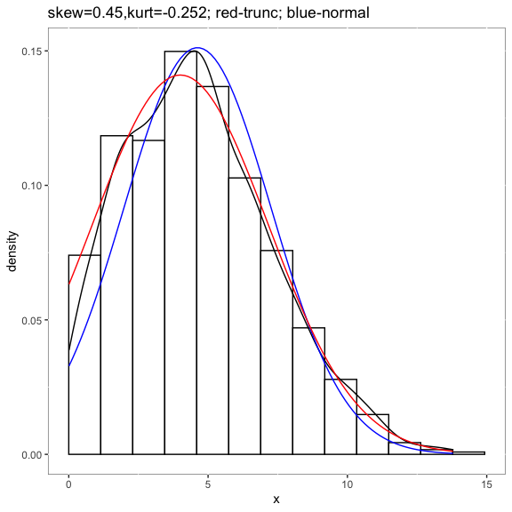

For one meta-analysis of two independent groups. It is very similar to the requirements for package `metafor` only you need to add one or two columns for each group about the possible minimum and maximum of the data. It will add information including:

- `g1_alpha`, `g1_beta`, `g2_alpha`, and `g2_beta` are the shape parameters of beta distributions;
- `g1_mean`, `g1_sd`, `g2_mean`, `g2_sd` are the means and standard deviations of the standard beta distribution (ranged from 0 to 1);
- `g1_skewness`, `g1_kurtosis`, `g2_skewness`, and `g2_kurtosis` are the skewness and kurtosis of the two groups.

In this example, it has contained the empirical skewness `skew1` and `skew2`, which are calculated from raw data.

```r
library(detectnorm)
# examine the meta-analysis dataset by simulating extremely non-normal distribution
# population mean1 = 1, mean2 = 1.5, sd1 = sd2=1, skewness1 = 4, kurtosis2 = 2, skewness2=-4, kurtosis2=2
data("beta_mdat")
beta1 <- detectnorm(m1i = m1,sd1i = sd1,n1i = n1, hi1i = hi1,lo1i = lo1,m2i = m2,sd2i = sd2,n2i = n2, hi2i = hi2,lo2i=lo2,distri = "beta", data = beta_mdat)
head(beta1)
```

```
#>   study  n1        m1       sd1       lo1      hi1  n2       m2       sd2
#> 1     1 160 1.0259203 0.8995642 0.2083603 5.578894 160 1.430021 1.0598447
#> 2     2  34 1.1528144 1.1367622 0.2123795 4.932592  34 1.408080 0.9296092
#> 3     3  57 0.9959042 0.8760782 0.2089018 3.443021  57 1.508927 1.0423997
#> 4     4 155 0.9480018 0.8828343 0.2082652 3.934242 155 1.443682 0.9198336
#> 5     5 149 1.1162247 1.0968963 0.2081850 5.613920 149 1.444312 1.0826183
#> 6     6 132 1.0418582 0.8946956 0.2082168 4.301961 132 1.554712 0.7932896
#>         lo2      hi2    skew1     skew2  g1_alpha  g1_beta   g1_mean     g1_sd
#> 1 -3.177617 2.274204 1.788613 -2.230054 0.5480186 3.051904 0.1522307 0.1674999
#> 2 -1.296619 2.271800 1.655752 -1.232207 0.3488177 1.401962 0.1992357 0.2408286
#> 3 -2.287307 2.274883 1.292354 -1.627030 0.3672680 1.141989 0.2433436 0.2708861
#> 4 -2.072880 2.274900 1.530104 -1.560090 0.3641696 1.470115 0.1985349 0.2369403
#> 5 -4.294234 2.274901 1.541182 -2.244364 0.4022054 1.992201 0.1679771 0.2029134
#> 6 -2.987192 2.273312 1.508507 -2.096631 0.4877450 1.907413 0.2036379 0.2185519
#>   g1_skewness g1_kurtosis g2_alpha   g2_beta   g2_mean     g2_sd g2_skewness
#> 1    1.483046   1.8901609 2.081468 0.3813533 0.8451559 0.1944020   -1.591348
#> 2    1.331854   0.8377363 1.291009 0.4122712 0.7579545 0.2605101   -1.069528
#> 3    1.079966   0.0309162 1.394623 0.2813890 0.8321080 0.2284867   -1.581618
#> 4    1.327314   0.8548620 1.985434 0.4693019 0.8088177 0.2115640   -1.310686
#> 5    1.489420   1.5984400 2.678914 0.3877426 0.8735618 0.1648038   -1.789508
#> 6    1.234109   0.7489875 3.614481 0.5718672 0.8633971 0.1508011   -1.558126
#>   g2_kurtosis
#> 1  2.00489688
#> 2  0.07531228
#> 3  1.66667585
#> 4  1.00447883
#> 5  3.02270945
#> 6  2.29997673
```

```r
#compare the sample skewness and estimated skewness using beta distribution
mean(beta1$skew1)#sample skewness calculated from the sample in group 1
```

```
#> [1] 1.687593
```

```r
mean(beta1$g1_skewness) #estimated using beta in group 1
```

```
#> [1] 1.384237
```

```r
mean(beta1$skew2) #sample skewness calculated from the sample in group 2
```

```
#> [1] -1.687784
```

```r
mean(beta1$g2_skewness)#estimated using beta in group 2
```

```
#> [1] -1.411431
```

```r
library(detectnorm)
data("trun_mdat")
head(trun_mdat)
```

```
#>   study  n1       m1       sd1          lo1      hi1  n2       m2       sd2
#> 1     1 199 1.297501 0.8203794 0.0061563102 3.611959 199 1.572915 0.9002734
#> 2     2  77 1.325658 0.7750929 0.0231261133 2.889290  77 1.597681 0.8782761
#> 3     3 166 1.212825 0.7460359 0.0158618581 3.607032 166 1.612654 0.8441273
#> 4     4 120 1.230577 0.7888702 0.0030294235 3.443851 120 1.598539 0.8776627
#> 5     5 175 1.279821 0.7477283 0.0002848415 3.409888 175 1.612636 0.8426223
#> 6     6  47 1.310062 0.8904328 0.0088877511 3.729032  47 1.613387 0.8375352
#>          lo2      hi2     skew1       skew2
#> 1 0.02056929 3.654732 0.4925754  0.31062433
#> 2 0.01601133 3.591504 0.3189877  0.31978670
#> 3 0.02598881 3.944059 0.8236975  0.41657818
#> 4 0.05609411 3.563257 0.5632971  0.17020660
#> 5 0.01150730 3.784293 0.4826745  0.20444248
#> 6 0.04276128 3.137731 0.7678702 -0.02343749
```

```r
trun1 <- detectnorm(m1i = m1,sd1i = sd1,n1i = n1, hi1i = 4,lo1i = 0,m2i = m2,sd2i = sd2,n2i = n2, hi2i = 4,lo2i= 0,distri = "truncnorm", data = trun_mdat)
mean(trun1$skew1)#sample skewness calculated from the sample in group 1
```

```
#> [1] 0.5142782
```

```r
mean(trun1$g1_skewness)#estimated using truncnorm in group 1
```

```
#> [1] 0.5198264
```

```r
mean(trun1$skew2)#sample skewness calculated from the sample in group 2
```

```
#> [1] 0.2023012
```

```r
mean(trun1$g2_skewness)#estimated using truncnorm in group 2
```

```
#> [1] 0.254666
```